# Ford GoBike 2008 Investigation

Ford GoBike is a bike-sharing system covering 5 cities. In this project I will be descoviring the greater San Francisco Bay area.  
Data analysis had done on year 2008. The data is provided by [www.fordgobike.com](https://www.fordgobike.com/system-data) and it has 1863721 observations with 16 variables. The reason I chosed this data-set becuase it provide enough observations and variables that can be analysed.  
For more exploration I have downloaded weather data-set by [National Centers for Environmental Information](https://www.ncdc.noaa.gov).

## When are most trips taken in terms of time of day, day of the week, or month of the year?

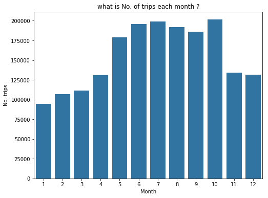

```python
base_color = sns.color_palette()[0]

plt.figure(figsize=(8,6))
sns.countplot(df.start_time.dt.month, color=base_color);
plt.title('what is No. of trips each month ?')
plt.xlabel('Month')
plt.ylabel('No. trips');
```

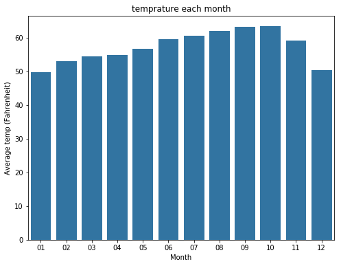

```python
plt.figure(figsize=(8,6))
sns.barplot('MONTH', 'TAVG', data=df_weather, color=base_color);
plt.title('temprature each month')
plt.xlabel('Month')
plt.ylabel('Average temp (Fahrenheit)');
```

It seems there is a quite relation with weather temprature.

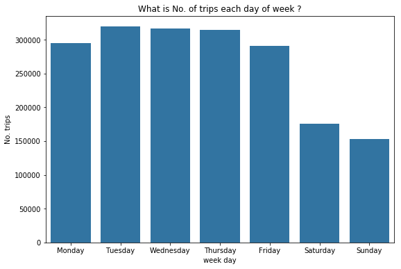

```python
# setting figure size
plt.figure(figsize=(9,6))

# list for order of xlable
order = ['Monday', 'Tuesday', 'Wednesday', 'Thursday', 'Friday', 'Saturday', 'Sunday']
sns.countplot(df.start_time.dt.day_name(), color=base_color, order=order);

# plotting title and lables
plt.title('What is No. of trips each day of week ?')
plt.xlabel('week day')
plt.ylabel('No. trips');
```

It is obvois that business days have higher peak than the weekend.

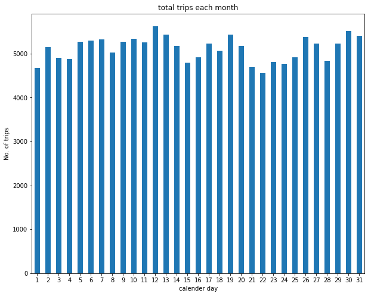

```python
# setting the figure size
plt.figure(figsize=(10,8))

# create datetime object from start_time column to be the index
index = pd.DatetimeIndex(df.start_time)
df1 = df.reindex(index=index)

# group them by day
df1 = df1.resample('D').size()
df1.groupby(df1.index.day).mean().plot('bar', color=base_color)

# setting x ticks rotation to be 0
plt.xticks(rotation=0)

# plotting the title and lables
plt.title('total trips each month')
plt.xlabel('calender day')
plt.ylabel('No. of trips');
```

## How long does the average trip take?

```python
df.duration_sec.mean() // 60
```

```
14.0
```

The average ride for all trips is 14 minutes.

## Does the above depend on if a user is a subscriber or customer?

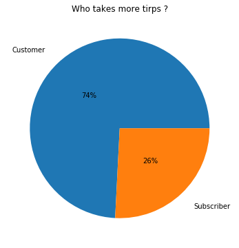

```python
df.groupby('user_type').duration_sec.mean().plot('pie', autopct='%1.0f%%', pctdistance=0.5, labeldistance=1.2, figsize=(8,6))
plt.ylabel('')
plt.title('Who takes more tirps ?');
```

## Gender distripution ?

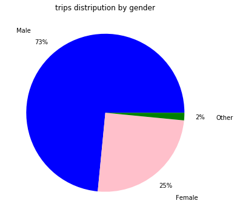

```python
# setting colors for the plot
colors = ['blue', 'pink', 'green']

df.member_gender.value_counts().plot('pie', autopct='%1.0f%%', pctdistance=1.2, labeldistance=1.4, figsize=(8,6), colors=colors);
# wipe ylable and plotting title
plt.ylabel('')
plt.title('trips distripution by gender');
```

The majority of gender is male with 73%. The female perecentage is 25%

## Average trip duration by gender

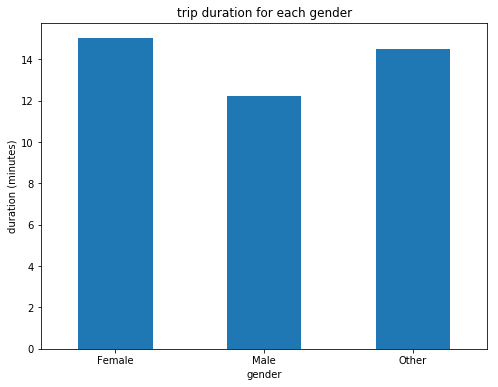

```python
plt.figure(figsize=(8,6))
(df.groupby('member_gender').duration_sec.mean() / 60).plot('bar')
plt.xticks(rotation=0);
plt.title('trip duration for each gender')
plt.xlabel('gender')
plt.ylabel('duration (minutes)');
```

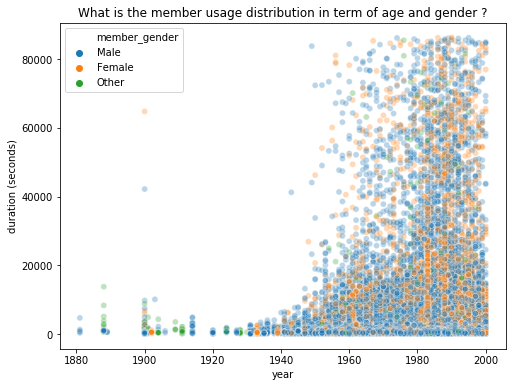

```python
plt.figure(figsize=(8,6))
sns.scatterplot('member_birth_year', 'duration_sec', hue='member_gender', data=df,alpha= 0.3);
plt.title('What is the member usage distribution in term of age and gender ?')
plt.xlabel('year')
plt.ylabel('duration (seconds)');
```

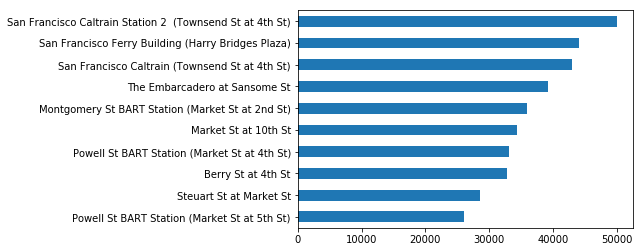

```python
df.end_station_name.value_counts()[:10].sort_values().plot('barh', color=base_color);
```

## most used bike

```python
df.groupby('bike_id').duration_sec.sum().sort_values(ascending=False)[:10] //3600
```

```
bike_id
3961    330
3235    324
4452    294
1181    291
2970    288
2237    285
3570    283
3614    278
1298    273
2375    271
Name: duration_sec, dtype: int64
```

The most used bike used for 330 hours followed by a bike use for 324 hours. Well let's see the bike's usage distribution.

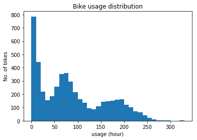

```python
bins = np.arange(0, 330+10, 10)
(df.groupby('bike_id').duration_sec.sum() //3600).plot('hist', bins=bins);
plt.title('Bike usage distribution')
plt.ylabel('No. of bikes')
plt.xlabel('usage (hour)');
```

It looks that we have interesting distribution. some bikes are rarly used with about 10 to 20 hours of usage and we have another spike with about 70 to 90 hours and another spike with about 160 to 200 hours.

# conclusion

With 331 stations in San Francicso and over 1.86 million trips has been taken on 2008.The analysis shows that the bike share system is more active on business days than weekends. In terms of months there is a spike from May to Oct. We have seen some relation with weather Temprature. The analysis shows that Female take longer ride duration than male. We have seen how the bike usage distributed.

# Done By Yousef Alamri

# Supervised by Udacity.com